# Exploring the BRFSS data

## Setup

### Load packages

```r
library(ggplot2)
library(dplyr)
library(tidyverse)
```

### Load data

```r
load("brfss2013.RData")
```

## Part 1: Data

Information regarding data collection: - BRFSS conducts both landline telephone- and cellular telephone-based surveys - In conducting the BRFSS landline telephone survey, interviewers collect data from a **randomly selected** adult in a household. - In conducting the cellular telephone version of the BRFSS questionnaire, interviewers collect data from an adult who participates by using a cellular telephone and resides in a private residence or college housing.

conclusions about the data: - *generalizability*: The data collected by landline telephone is generalizable since participants were randomly. It is important to note that those contacted by cellular telephone must have a cellular tellephone, and reside in private residence or college housing. Thus, the data collected by cellular telephone isnt generalizable. - *casuality*: casuality (also known as casuation) can only be determined through random assignment in an experiment, thus we cannot determine casuality here

## Part 2: Research questions

### **Research quesion 1:**

Is there a difference between month (**imonth** : *Interview Month*) and Health-Related Quality of Life (determined by: **physhlth**: *Number Of Days Physical Health Not Good*, **menthlth**: *Number Of Days Mental Health Not Good*). I expect a higher reported # of days for phshlth, menthlth, and poorhlth for the winter month than the summer.

**physhlth**: Now thinking about your physical health, which includes physical illness and injury, for how many days during the past 30 days was your physical health not good?

**menthlth**: Now thinking about your mental health, which includes stress, depression, and problems with emotions, for how many days during the past 30 days was your mental health not good?

If participants have more days in which their mental and physical health is not good, this information could be used by non-profits or other initiatives that address mental and physical health. If mental health is worse in the winter months, then orgnaizations might allocate more of their outreach budget in those months.

### **Research quesion 2:**

Is there a difference in health care access based on income levels (**income2**: *Income Level*)

Health Care Access **hlthpln1**: *Have Any Health Care Coverage* **persdoc2**: *Multiple Health Care Professionals* **medcost**: *Could Not See Dr. Because Of Cost* **checkup1**: *Length Of Time Since Last Routine Checkup*

I expect that lower income levels will have lower access to health care

### **Research quesion 3:**

Is there a difference of general health (**genhlth**: *General Health*) by state (**_state**: *State Fips Code*)?

## Part 3: Exploratory data analysis

### **Research quesion 1:**

```r
#select columns I want into new data frame called college_health
month_health = brfss2013 %>%
  select(imonth, physhlth, menthlth)

#look at first five rows
head(month_health)
```

```
##     imonth physhlth menthlth
## 1  January       30       29
## 2  January        0        0
## 3  January        3        2
## 4  January        2        0
## 5 February       10        2
## 6    March        0        0
```

#### data information & descriptive statistics

```r
#look at data types
lapply(month_health, class)
```

```
## $imonth
## [1] "factor"
##
## $physhlth
## [1] "integer"
##
## $menthlth
## [1] "integer"
```

```r
#look at number of na in each column
sapply(month_health, function(x) sum(is.na(x)))
```

```
##   imonth physhlth menthlth
##        3    10957     8627
```

```r
#drop na
month_health = na.omit(month_health)
```

```r
#look at summary of descriptive statistics
summary(month_health)
```

```
##       imonth          physhlth         menthlth
##  March   : 42989   Min.   : 0.000   Min.   :  0.000
##  July    : 42094   1st Qu.: 0.000   1st Qu.:  0.000
##  April   : 41474   Median : 0.000   Median :  0.000
##  February: 41430   Mean   : 4.298   Mean   :  3.359
##  August  : 40737   3rd Qu.: 3.000   3rd Qu.:  2.000
##  October : 40729   Max.   :30.000   Max.   :247.000
##  (Other) :225121
```

- majority of people answered 0 for physhlth looking at the mean & the median

#### plots

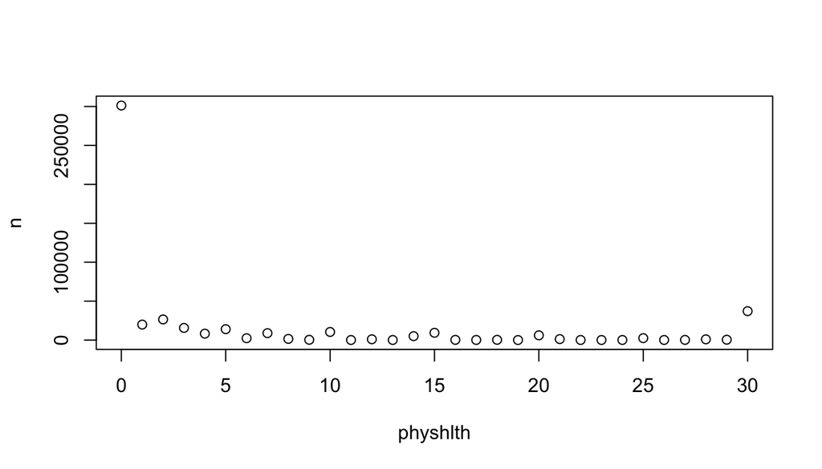

```r
#look at count for each & plot
#I didnt use a histogram because the values are ordinal, instead I plotted the count for each value 0-30
month_health %>%
     group_by(physhlth) %>%
      count() %>%
      plot()
```

```r
#most counts in the extreme values
```

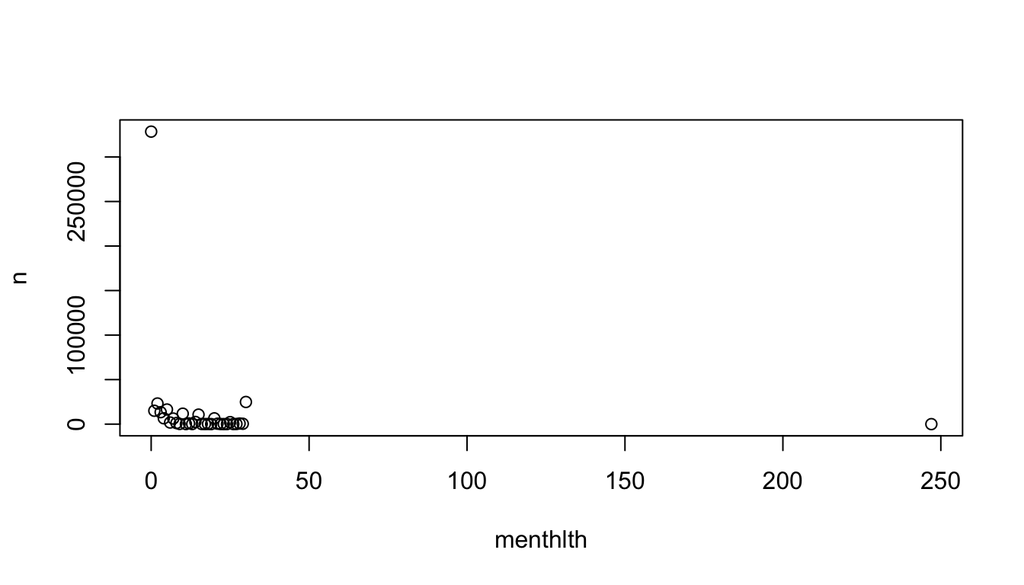

```r
#look at count for each & plot
month_health %>%
     group_by(menthlth) %>%
      count() %>%
      plot()
```

- there must be a mistake here because the values should be from 0 to 30. Need to remove this row, then replot

```r
dim(month_health)
```

```
## [1] 474574      3
```

```r
month_health = filter(month_health, menthlth <= 30)

#we can see we lost that one row now
dim(month_health)
```

```
## [1] 474573      3
```

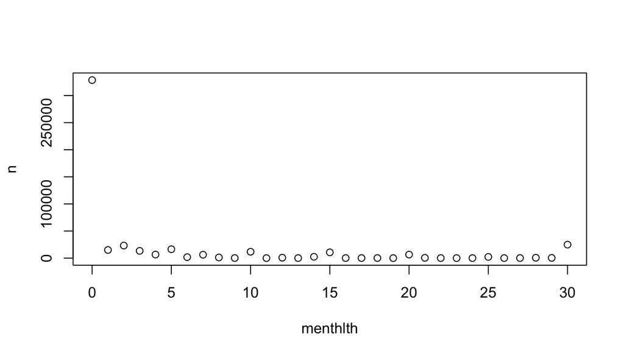

```r
#look at count for each & plot again for menthlth
month_health %>%
     group_by(menthlth) %>%
      count() %>%
      plot()
```

- again higher count on the extremes

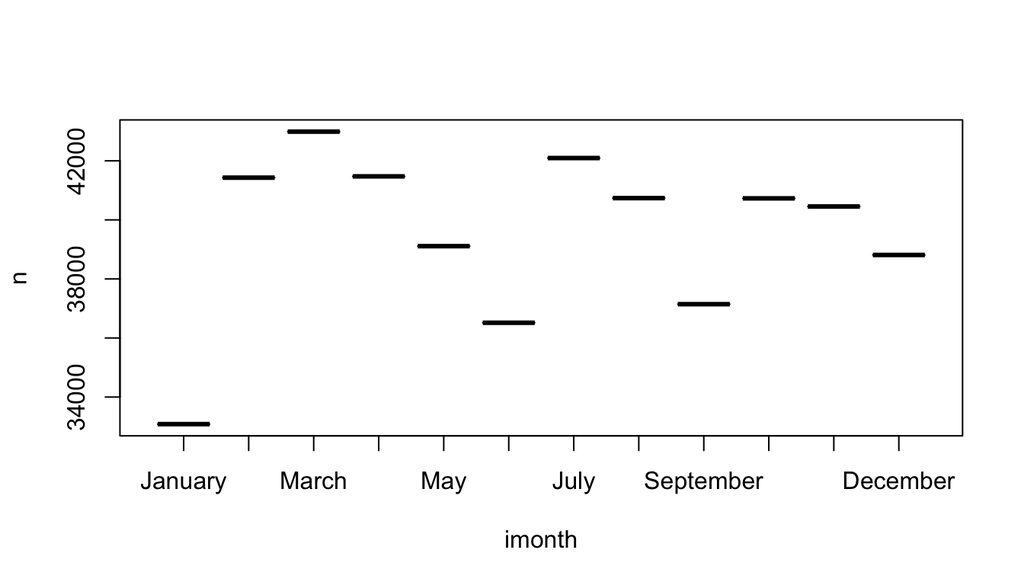

```r
#look at count for each month to see if one month has more collected data
month_health %>%
     group_by(imonth) %>%
      count() %>%
      plot()
```

- there was a lot more data collected in some months, and a significantly less amount of data collected in January. This will be needed to keep in mind going forward. Since the menthlth and physhlth are skewed toward the extremes, I will use the median as a measure going forward

-Next, I will plot the medianfor physhlth and menthlth by each month - MEDIAN: looking at median because data is composed of more extreme scores

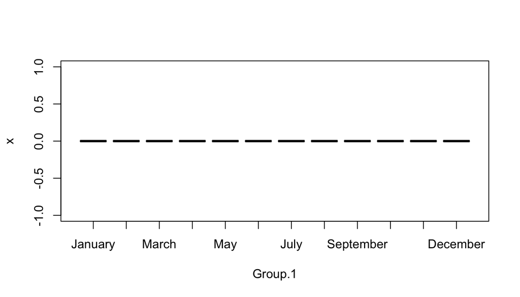

```r
plot(aggregate(month_health$physhlth,
          list(month_health$imonth),
          median))

plot(aggregate(month_health$menthlth,
          list(month_health$imonth),
          median))
```

[output not shown]

```r
#the median is 0 for all months in both menthlth and physhtl
```

```r
#since the data is ordinal, im going to change the physhlth & menthlth to factors as well
month_health$physhlth <- as.factor(month_health$physhlth)
month_health$menthlth <- as.factor(month_health$menthlth)

#look at data types
lapply(month_health, class)
```

```
## $imonth
## [1] "factor"
##
## $physhlth
## [1] "factor"
##
## $menthlth
## [1] "factor"
```

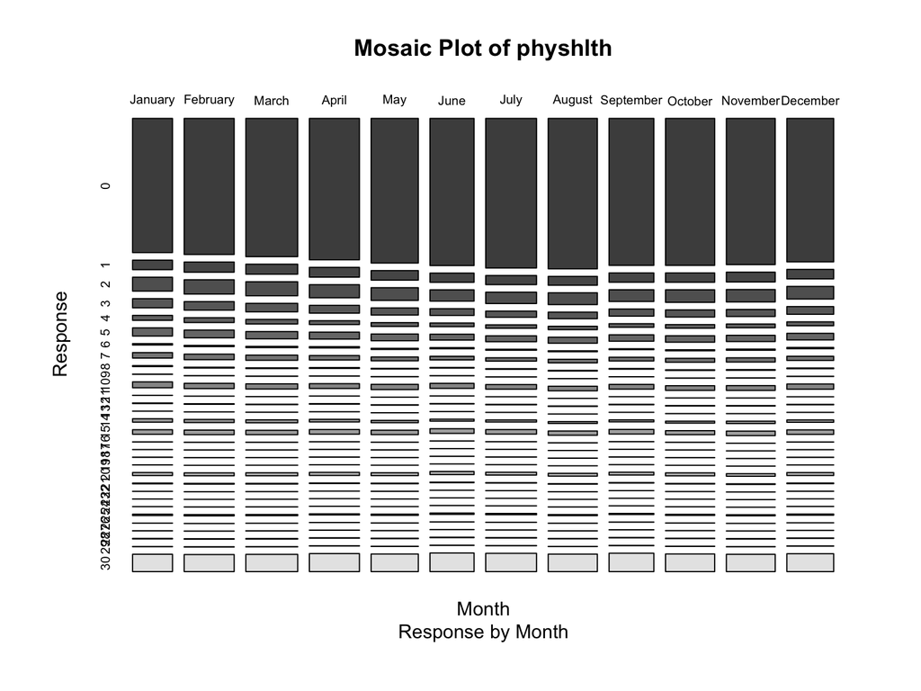

```r
#median of physhlth
table1 <- table(month_health$imonth, month_health$physhlth)
mosaicplot(table1, main = "Mosaic Plot of physhlth",
           sub = "Response by Month",
           xlab = "Month",
           ylab = "Response",
           color = TRUE)
```

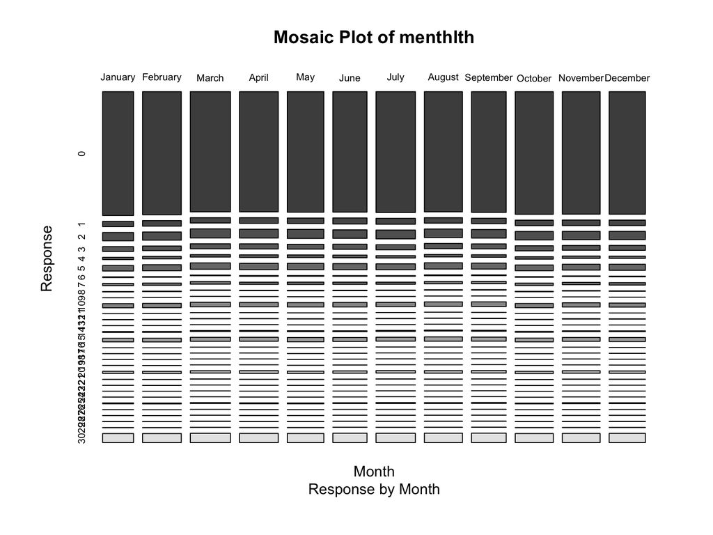

```r
#median of physhlth
table1 <- table(month_health$imonth, month_health$menthlth)
mosaicplot(table1, main = "Mosaic Plot of menthlth",
           sub = "Response by Month",
           xlab = "Month",
           ylab = "Response",
           color = TRUE)
```

#### conclusions

- based on the uneven number of per month, it is difficult to acertain whether responses changes from month to month.
- For physhlth, it seems as though there is a slight increase in percentage people who respond 0 (0 days have had poor physical health) in the summer months than the winter months
- For menthtl, there does not seem to be change in percentange of people per response by month

###**Research quesion 2:**

**income2**: *Income Level* **hlthpln1**: *Have Any Health Care Coverage* **persdoc2**: *Multiple Health Care Professionals* **medcost**: *Could Not See Dr. Because Of Cost* **checkup1**: *Length Of Time Since Last Routine Checkup*

```r
#select columns I want into new data frame called college_health
health_access = brfss2013 %>%
  select(income2, hlthpln1, persdoc2, medcost, checkup1)

#look at first five rows
head(health_access)
```

```
##             income2 hlthpln1      persdoc2 medcost            checkup1
## 1 Less than $75,000      Yes Yes, only one      No    Within past year
## 2   $75,000 or more      Yes Yes, only one      No    Within past year
## 3   $75,000 or more      Yes Yes, only one      No    Within past year
## 4 Less than $75,000      Yes Yes, only one      No Within past 2 years
## 5 Less than $50,000      Yes Yes, only one      No 5 or more years ago
## 6   $75,000 or more      Yes Yes, only one      No    Within past year
```

```r
# look at values in each column
for(col in colnames(health_access)){
  print(unique(health_access[col]))
}
```

```
##              income2
## 1  Less than $75,000
## 2    $75,000 or more
## 5  Less than $50,000
## 7               <NA>
## 10 Less than $25,000
## 12 Less than $10,000
## 17 Less than $20,000
## 34 Less than $35,000
## 42 Less than $15,000
##     hlthpln1
## 1        Yes
## 12        No
## 800     <NA>
##          persdoc2
## 1   Yes, only one
## 7   More than one
## 11             No
## 561          <NA>
##     medcost
## 1        No
## 11      Yes
## 332    <NA>
##                checkup1
## 1      Within past year
## 4   Within past 2 years
## 5   5 or more years ago
## 28  Within past 5 years
## 45                 <NA>
## 172               Never
```

```r
#look at data types
lapply(health_access, class)
```

```
## $income2
## [1] "factor"
##
## $hlthpln1
## [1] "factor"
##
## $persdoc2
## [1] "factor"
##
## $medcost
## [1] "factor"
##
## $checkup1
## [1] "factor"
```

```r
#look at number of na in each column
sapply(health_access, function(x) sum(is.na(x)))
```

```
##  income2 hlthpln1 persdoc2  medcost checkup1
##    71426     1904     1801     1221     6305
```

```r
#drop na
health_access = na.omit(health_access)
```

```r
#look at summary of descriptive statistics
summary(health_access)
```

```
##               income2       hlthpln1              persdoc2      medcost
##  $75,000 or more  :114898   Yes:367038   Yes, only one:312636   Yes: 51683
##  Less than $75,000: 64458   No : 46390   More than one: 34100   No :361745
##  Less than $50,000: 60647                No           : 66692
##  Less than $35,000: 47964
##  Less than $25,000: 40876
##  Less than $20,000: 34022
##  (Other)          : 50563
##                 checkup1
##  Within past year   :301123
##  Within past 2 years: 49637
##  Within past 5 years: 29528
##  5 or more years ago: 29432
##  Never              :  3708
##
##
```

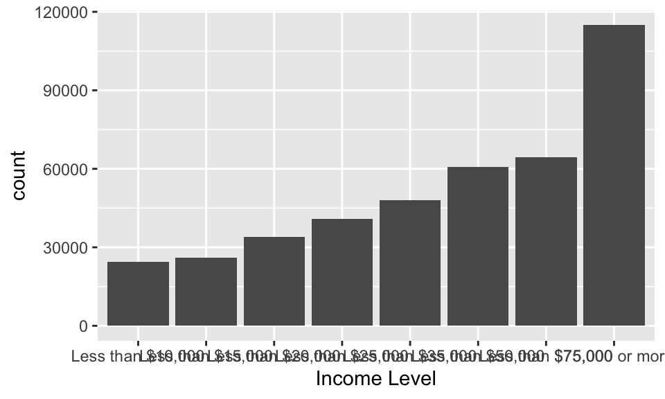

```r
#look at count for each
#I didnt use a histogram because the values are ordinal, instead I plotted the count for each value 0-30
ggplot(health_access) + geom_bar(aes(x = income2))  + xlab("Income Level")
```

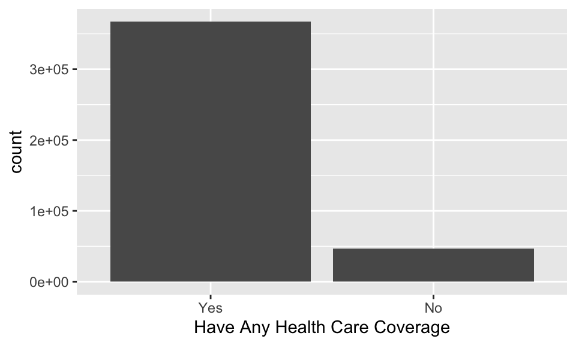

```r
ggplot(health_access) + geom_bar(aes(x = hlthpln1)) + xlab("Have Any Health Care Coverage")
```

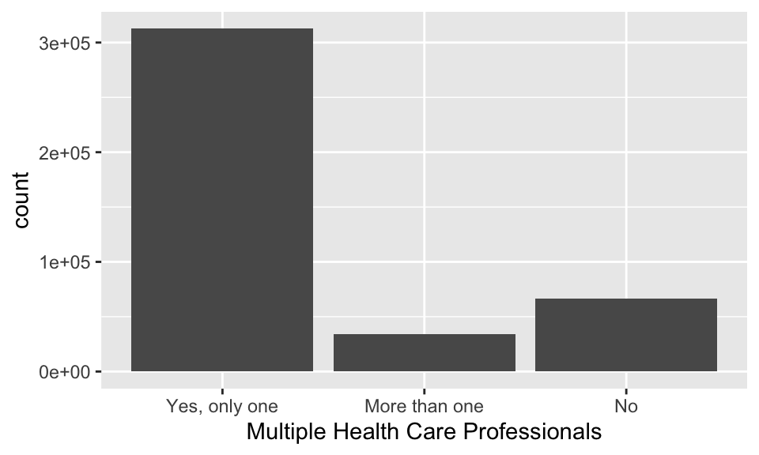

```r
ggplot(health_access) + geom_bar(aes(x = persdoc2)) + xlab("Multiple Health Care Professionals")
```

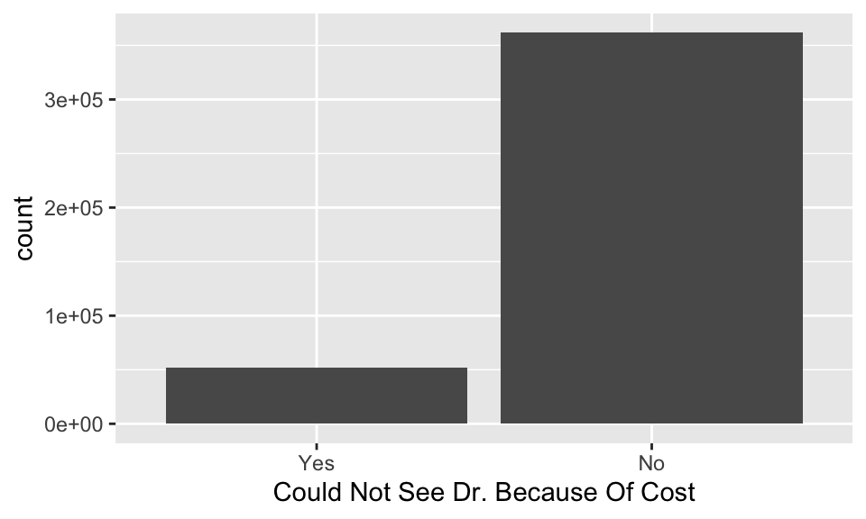

```r
ggplot(health_access) + geom_bar(aes(x = medcost)) + xlab("Could Not See Dr. Because Of Cost")
```

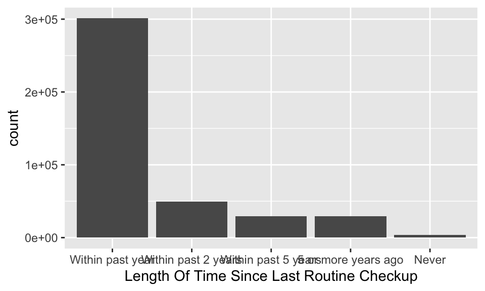

```r
ggplot(health_access) + geom_bar(aes(x = checkup1)) + xlab("Length Of Time Since Last Routine Checkup")
```

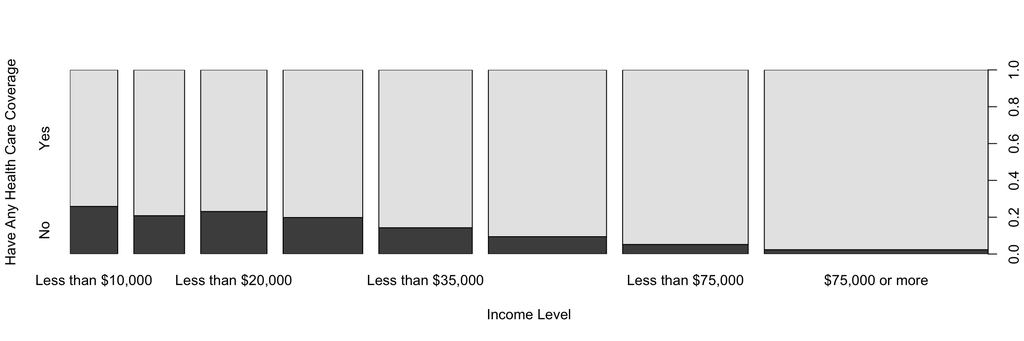

```r
plot(health_access$income2, health_access$hlthpln1, xlab = "Income Level", ylab = "Have Any Health Care Coverage" )
```

- As income bracket increases, the percentage of those surveyed that dont have health insurance decrease

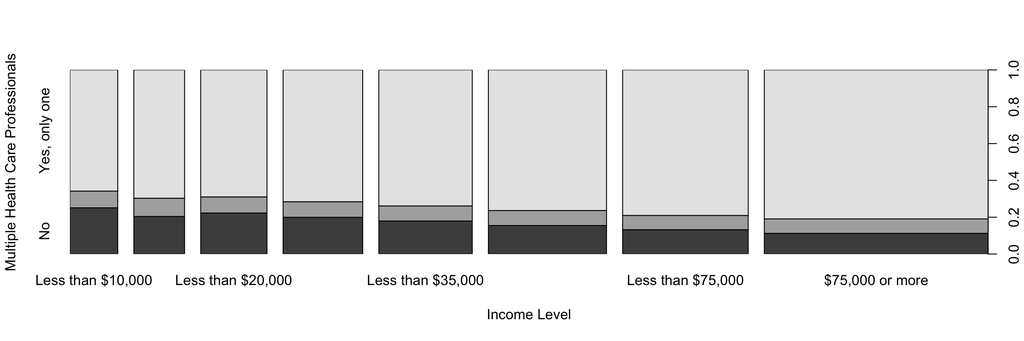

```r
plot(health_access$income2, health_access$persdoc2, xlab = "Income Level", ylab = "Multiple Health Care Professionals")
```

- As income bracket increases, the percentage of those with at least one health care professionals increases

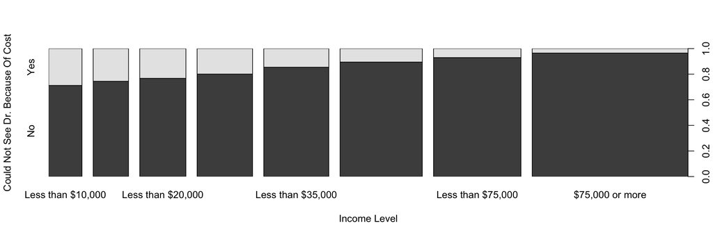

```r
plot(health_access$income2, health_access$medcost, xlab = "Income Level", ylab = "Could Not See Dr. Because Of Cost")
```

- As income bracket increases, the percentage of those who could not see a doctor because of cost decreased

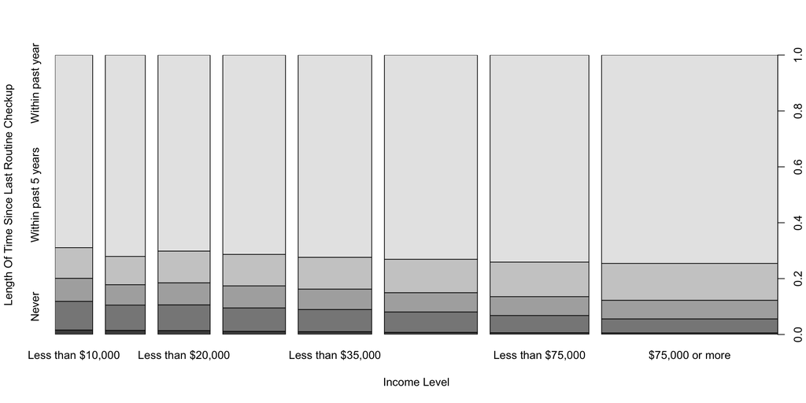

```r
plot(health_access$income2, health_access$checkup1, xlab = "Income Level", ylab = "Length Of Time Since Last Routine Checkup")
```

- the percentage of people who have had a checkup within the past year is increases slightly with increased income level

###**Research quesion 3:**

```r
#select columns I want into new data frame called college_health
state_health = brfss2013 %>%
  select(genhlth, X_state)

#look at first five rows
head(state_health)
```

```
##     genhlth X_state
## 1      Fair Alabama
## 2      Good Alabama
## 3      Good Alabama
## 4 Very good Alabama
## 5      Good Alabama
## 6 Very good Alabama
```

```r
#look at data types
lapply(state_health, class)
```

```
## $genhlth
## [1] "factor"
##
## $X_state
## [1] "factor"
```

```r
#look at number of na in each column
sapply(state_health, function(x) sum(is.na(x)))
```

```
## genhlth X_state
##    1985       0
```

```r
#drop na
state_health = na.omit(state_health)
```

```r
#look at summary of descriptive statistics
summary(state_health)
```

```
##       genhlth                X_state
##  Excellent: 85482   Florida      : 33305
##  Very good:159076   Kansas       : 23228
##  Good     :150555   Nebraska     : 17106
##  Fair     : 66726   Massachusetts: 15042
##  Poor     : 27951   Minnesota    : 14299
##                     New Jersey   : 13735
##                     (Other)      :373075
```

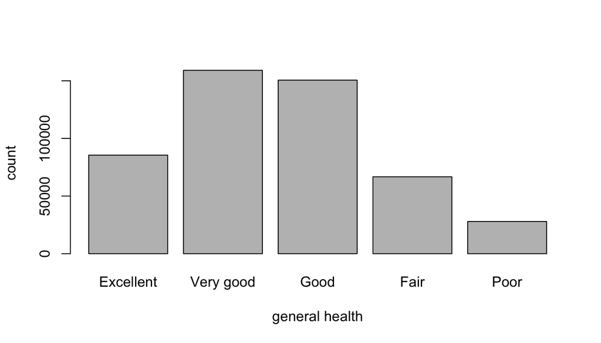

```r
#look at summary of descriptive statistics
plot(state_health$genhlth, xlab = "general health", ylab = "count")
```

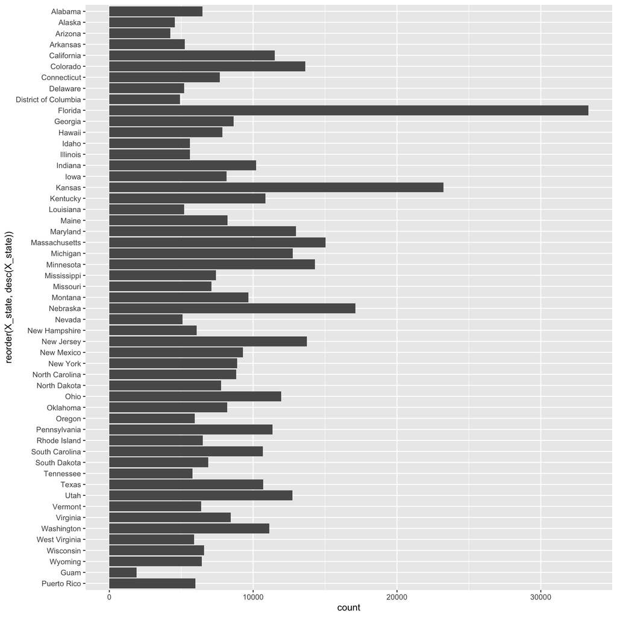

```r
ggplot(state_health, aes(x = reorder(X_state, desc(X_state)))) + geom_bar() + coord_flip()
```

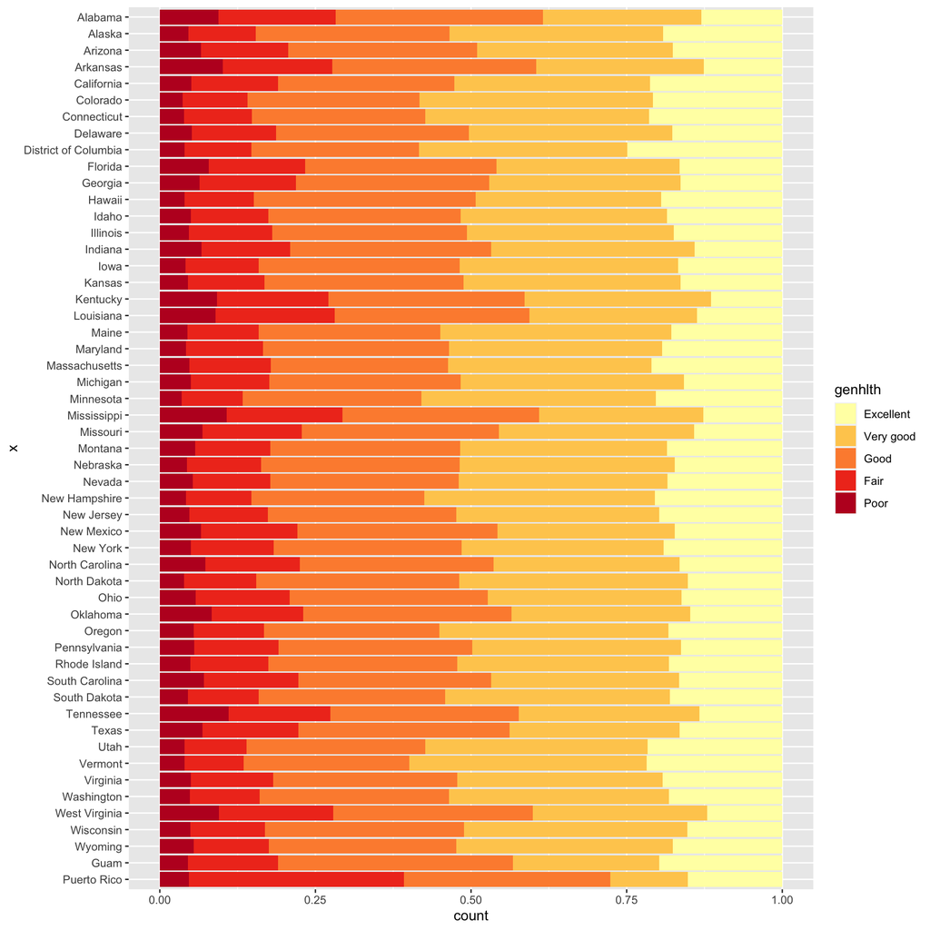

```r
#reodering states to be in alphabetical order
x = reorder(state_health$X_state, desc(state_health$X_state))


ggplot(state_health, aes(x=x, fill = genhlth)) +
    geom_bar(position="fill") + coord_flip() +  scale_fill_manual(values=c("#ffffb2", "#fecc5c", "#fd8d3c", "#f03b20", "#bd0026"))
```

- Here we can see the general health of participants by state